# my title

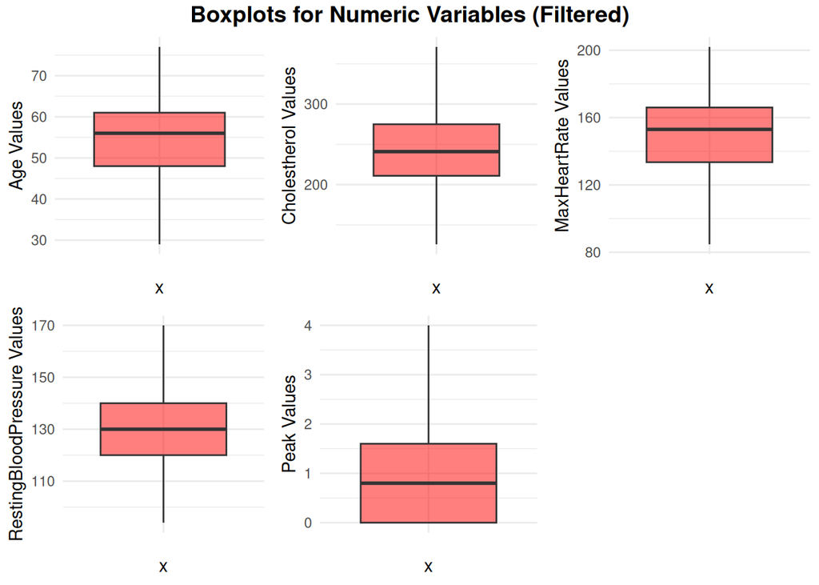

```r
# Function to remove outliers using the interquartile range (IQR)
remove_outliers_column <- function(x) {
  # Calculate the interquartile range (IQR) of the variable
  iqr_val <- IQR(x, na.rm = TRUE)

  # Define the lower and upper limits to consider a value as an outlier
  lower_bound <- quantile(x, 0.25, na.rm = TRUE) - 1.5 * iqr_val
  upper_bound <- quantile(x, 0.75, na.rm = TRUE) + 1.5 * iqr_val

  # Replace values that are outside the limits with the closest boundary values
  x[x < lower_bound] <- lower_bound
  x[x > upper_bound] <- upper_bound

  # Return the variable without outliers
  return(x)
}

# Create a copy of the original dataset to store the filtered data
heart_df_filtered <- heart_df

# List of numeric columns where outliers will be removed
columns_to_filter <- c("Age", "Cholestherol", "MaxHeartRate", "RestingBloodPressure", "Peak")

# Apply the remove_outliers_column function to each selected column
for (col in columns_to_filter) {
  heart_df_filtered[[col]] <- remove_outliers_column(heart_df[[col]])
}

# Create boxplots without outliers
plot1_filtered <- ggplot(heart_df_filtered, aes(x = "", y = Age)) +
  geom_boxplot(fill = "red", alpha = 0.5) +
  labs(y = "Age Values") +
  theme_minimal() +
  theme(plot.title = element_text(size = 12))

plot2_filtered <- ggplot(heart_df_filtered, aes(x = "", y = Cholestherol)) +
  geom_boxplot(fill = "red", alpha = 0.5) +
  labs(y = "Cholestherol Values") +
  theme_minimal() +
  theme(plot.title = element_text(size = 12))

plot3_filtered <- ggplot(heart_df_filtered, aes(x = "", y = MaxHeartRate)) +
  geom_boxplot(fill = "red", alpha = 0.5) +
  labs(y = "MaxHeartRate Values") +
  theme_minimal() +
  theme(plot.title = element_text(size = 12))

plot4_filtered <- ggplot(heart_df_filtered, aes(x = "", y = RestingBloodPressure)) +
  geom_boxplot(fill = "red", alpha = 0.5) +
  labs(y = "RestingBloodPressure Values") +
  theme_minimal() +
  theme(plot.title = element_text(size = 12))

plot5_filtered <- ggplot(heart_df_filtered, aes(x = "", y = Peak)) +
  geom_boxplot(fill = "red", alpha = 0.5) +
  labs(y = "Peak Values") +
  theme_minimal() +
  theme(plot.title = element_text(size = 12))

# Arrange the boxplots and add a general title
grid.arrange(
  arrangeGrob(plot1_filtered, plot2_filtered, plot3_filtered,
              plot4_filtered, plot5_filtered, ncol = 3),
  top = textGrob("Boxplots for Numeric Variables (Filtered)", gp = gpar(fontsize = 14, fontface = "bold"))
)
```

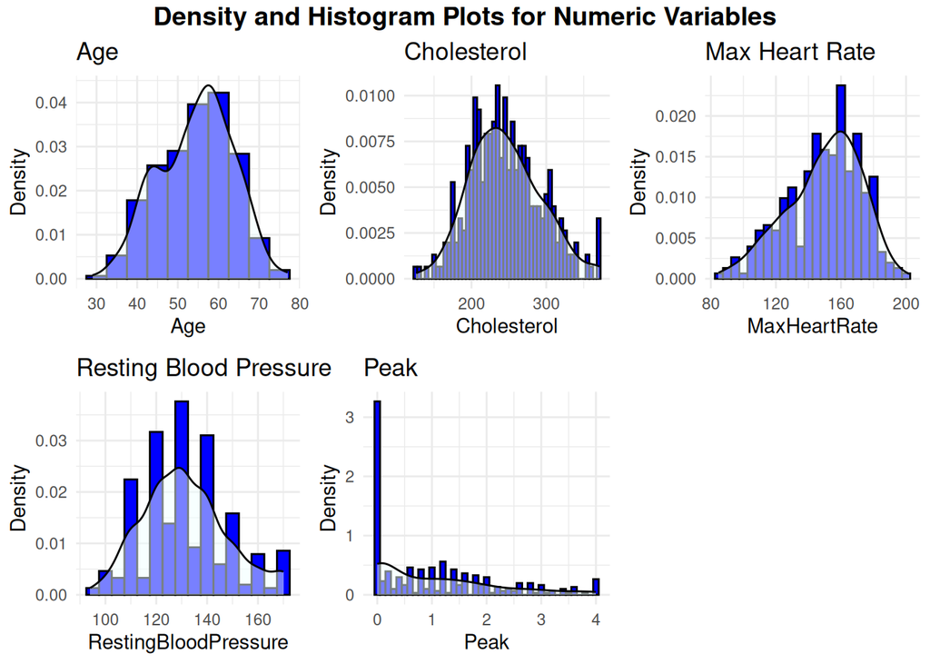

```r
# Create density plots and histograms to analyze the distribution of numeric variables
# Histograms are combined with density curves to visualize the shape of the distribution

# Density and histogram for the Age variable
plot_Age <- ggplot(data = heart_df_filtered, aes(x = Age)) +
  geom_histogram(aes(y = after_stat(density)), fill = 'blue1', color = 'black', binwidth = 5) +
  geom_density(fill = '#F0FFFF', alpha = 0.5) +
  labs(title = "Age", x = "Age", y = "Density") +
  theme_minimal()

# Density and histogram for the Cholestherol variable
plot_Cholestherol <- ggplot(data = heart_df_filtered, aes(x = Cholestherol)) +
  geom_histogram(aes(y = after_stat(density)), fill = 'blue1', color = 'black', binwidth = 5) +
  geom_density(fill = '#F0FFFF', alpha = 0.5) +
  labs(title = "Cholesterol", x = "Cholesterol", y = "Density") +
  theme_minimal()

# Density and histogram for the MaxHeartRate variable
plot_MaxHeartRate <- ggplot(data = heart_df_filtered, aes(x = MaxHeartRate)) +
  geom_histogram(aes(y = after_stat(density)), fill = 'blue1', color = 'black', binwidth = 5) +
  geom_density(fill = '#F0FFFF', alpha = 0.5) +
  labs(title = "Max Heart Rate", x = "MaxHeartRate", y = "Density") +
  theme_minimal()

# Density and histogram for the RestingBloodPressure variable
plot_RestingBloodPressure <- ggplot(data = heart_df_filtered, aes(x = RestingBloodPressure)) +
  geom_histogram(aes(y = after_stat(density)), fill = 'blue1', color = 'black', binwidth = 5) +
  geom_density(fill = '#F0FFFF', alpha = 0.5) +
  labs(title = "Resting Blood Pressure", x = "RestingBloodPressure", y = "Density") +
  theme_minimal()

# Density and histogram for the Peak variable
plot_Peak <- ggplot(data = heart_df_filtered, aes(x = Peak)) +
  geom_histogram(aes(y = after_stat(density)), fill = 'blue1', color = 'black', binwidth = 0.1) +
  geom_density(fill = '#F0FFFF', alpha = 0.5) +
  labs(title = "Peak", x = "Peak", y = "Density") +
  theme_minimal()

# Arrange the plots in a grid with a general title
grid.arrange(
  arrangeGrob(plot_Age, plot_Cholestherol, plot_MaxHeartRate,
              plot_RestingBloodPressure, plot_Peak, ncol = 3),
  top = textGrob("Density and Histogram Plots for Numeric Variables", gp = gpar(fontsize = 14, fontface = "bold"))
)
```

```r
# Set the significance level to 0.005
alpha <- 0.005

# Shapiro-Wilk normality test for numeric variables
shapiro_test_Age <- shapiro.test(heart_df_filtered$Age)
cat("Shapiro-Wilk test for Age:\n", "W =", shapiro_test_Age$statistic, ", p-value =", shapiro_test_Age$p.value, "\n\n")
```

```
## Shapiro-Wilk test for Age:
##  W = 0.9864633 , p-value = 0.006068642
```

```r
shapiro_test_Cholestherol <- shapiro.test(heart_df_filtered$Cholestherol)
cat("Shapiro-Wilk test for Cholestherol:\n", "W =", shapiro_test_Cholestherol$statistic, ", p-value =", shapiro_test_Cholestherol$p.value, "\n\n")
```

```
## Shapiro-Wilk test for Cholestherol:
##  W = 0.9888511 , p-value = 0.02006615
```

```r
shapiro_test_MaxHeartRate <- shapiro.test(heart_df_filtered$MaxHeartRate)
cat("Shapiro-Wilk test for MaxHeartRate:\n", "W =", shapiro_test_MaxHeartRate$statistic, ", p-value =", shapiro_test_MaxHeartRate$p.value, "\n\n")
```

```
## Shapiro-Wilk test for MaxHeartRate:
##  W = 0.9765386 , p-value = 7.244153e-05
```

```r
shapiro_test_RestingBloodPressure <- shapiro.test(heart_df_filtered$RestingBloodPressure)
cat("Shapiro-Wilk test for RestingBloodPressure:\n", "W =", shapiro_test_RestingBloodPressure$statistic, ", p-value =", shapiro_test_RestingBloodPressure$p.value, "\n\n")
```

```
## Shapiro-Wilk test for RestingBloodPressure:
##  W = 0.9745627 , p-value = 3.309576e-05
```

```r
shapiro_test_Peak <- shapiro.test(heart_df_filtered$Peak)
cat("Shapiro-Wilk test for Peak:\n", "W =", shapiro_test_Peak$statistic, ", p-value =", shapiro_test_Peak$p.value, "\n\n")
```

```
## Shapiro-Wilk test for Peak:
##  W = 0.8517292 , p-value = 2.155173e-16
```

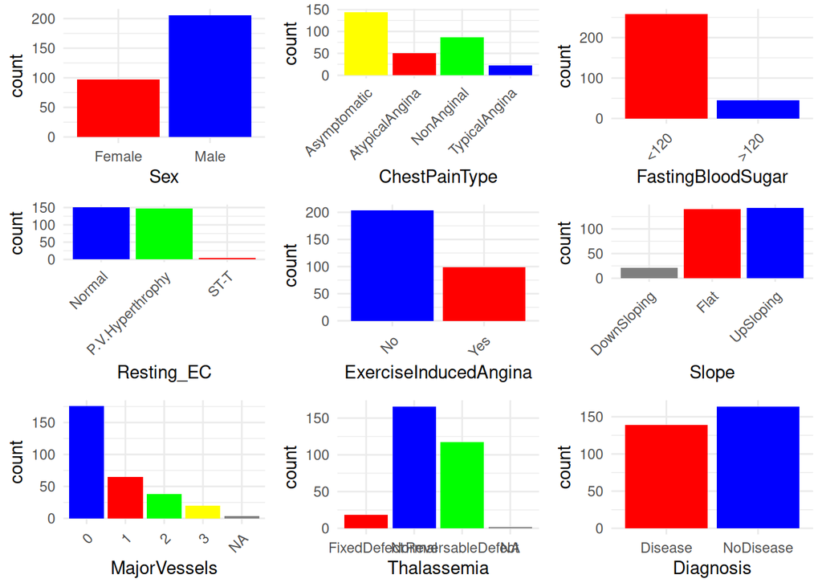

```r
# Create bar plots for categorical variables with blue, red, green, and yellow colors

# Distribution of the Sex variable (blue and red)
plot_sex <- ggplot(heart_df_filtered, aes(x = Sex, fill = Sex)) +
  geom_bar() +
  scale_fill_manual(values = c("Male" = "blue", "Female" = "red")) +
  theme_minimal() +
  theme(legend.position = "none")

# Distribution of the ChestPainType variable (blue, red, green, yellow)
plot_chest_pain <- ggplot(heart_df_filtered, aes(x = ChestPainType, fill = ChestPainType)) +
  geom_bar() +
  scale_fill_manual(values = c("TypicalAngina" = "blue", "AtypicalAngina" = "red", "NonAnginal" = "green", "Asymptomatic" = "yellow")) +
  theme_minimal() +
  theme(axis.text.x = element_text(angle = 45, hjust = 1), legend.position = "none")

# Distribution of the FastingBloodSugar variable (blue and red)
plot_fasting_blood_sugar <- ggplot(heart_df_filtered, aes(x = FastingBloodSugar, fill = FastingBloodSugar)) +
  geom_bar() +
  scale_fill_manual(values = c(">120" = "blue", "<120" = "red")) +
  theme_minimal() +
  theme(axis.text.x = element_text(angle = 45, hjust = 1), legend.position = "none")

# Distribution of the Resting_EC variable (blue, red, green)
plot_resting_ec <- ggplot(heart_df_filtered, aes(x = Resting_EC, fill = Resting_EC)) +
  geom_bar() +
  scale_fill_manual(values = c("Normal" = "blue", "ST-T" = "red", "P.V.Hyperthrophy" = "green")) +
  theme_minimal() +
  theme(axis.text.x = element_text(angle = 45, hjust = 1), legend.position = "none")

# Distribution of the ExerciseInducedAngina variable (blue and red)
plot_exercise_induced_angina <- ggplot(heart_df_filtered, aes(x = ExerciseInducedAngina, fill = ExerciseInducedAngina)) +
  geom_bar() +
  scale_fill_manual(values = c("No" = "blue", "Yes" = "red")) +
  theme_minimal() +
  theme(axis.text.x = element_text(angle = 45, hjust = 1), legend.position = "none")

# Distribution of the Slope variable (blue, red, green)
plot_slope <- ggplot(heart_df_filtered, aes(x = Slope, fill = Slope)) +
  geom_bar() +
  scale_fill_manual(values = c("UpSloping" = "blue", "Flat" = "red", "DownSlopping" = "green")) +
  theme_minimal() +
  theme(axis.text.x = element_text(angle = 45, hjust = 1), legend.position = "none")

# Distribution of the MajorVessels variable (blue, red, green, yellow)
plot_major_vessels <- ggplot(heart_df_filtered, aes(x = MajorVessels, fill = MajorVessels)) +
  geom_bar() +
  scale_fill_manual(values = c("0" = "blue", "1" = "red", "2" = "green", "3" = "yellow")) +
  theme_minimal() +
  theme(axis.text.x = element_text(angle = 45, hjust = 1), legend.position = "none")

# Distribution of the Thalassemia variable (blue, red, green)
plot_thalassemia <- ggplot(heart_df_filtered, aes(x = Thalassemia, fill = Thalassemia)) +
  geom_bar() +
  scale_fill_manual(values = c("Normal" = "blue", "FixedDefect" = "red", "ReversableDefect" = "green")) +
  theme_minimal() +
  theme(legend.position = "none")

# Distribution of the Diagnosis variable (blue and red)
plot_diagnosis <- ggplot(heart_df_filtered, aes(x = Diagnosis, fill = Diagnosis)) +
  geom_bar() +
  scale_fill_manual(values = c("NoDisease" = "blue", "Disease" = "red")) +
  theme_minimal() +
  theme(legend.position = "none")

# Arrange the bar plots in a grid for easier comparison
plot_grid(
  plot_sex, plot_chest_pain, plot_fasting_blood_sugar, plot_resting_ec,
  plot_exercise_induced_angina, plot_slope, plot_major_vessels,
  plot_thalassemia, plot_diagnosis, ncol = 3
)
```

## Create visualizations in order to show which variables seem to be more associated with heart disease

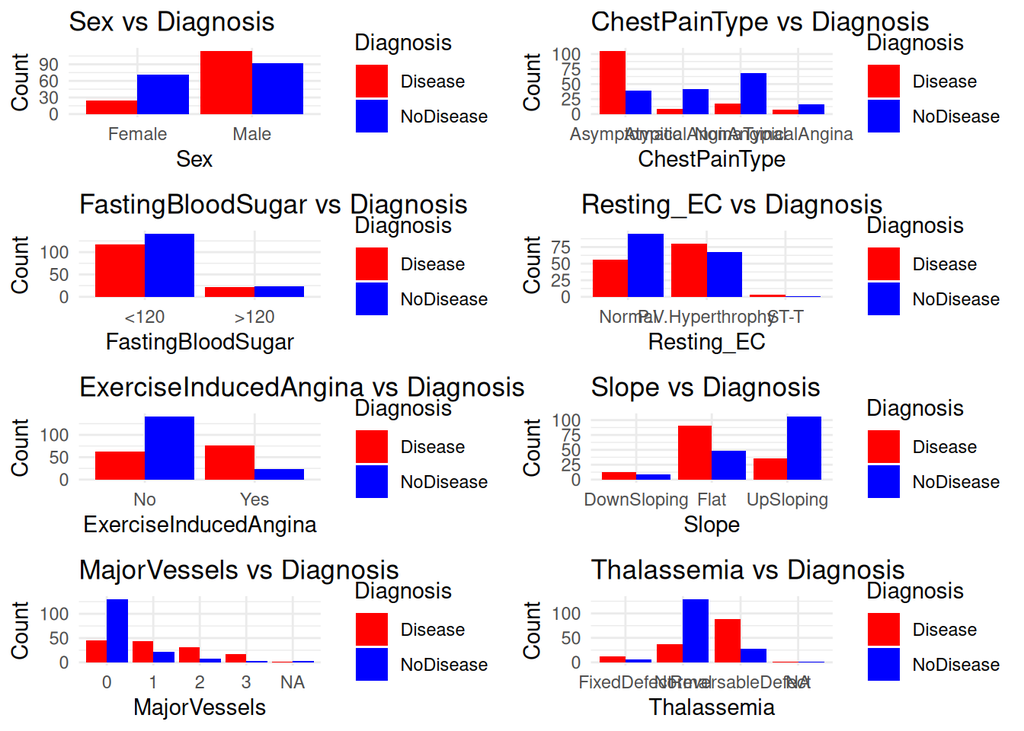

```r
# List of categorical variables to analyze in relation to heart disease diagnosis
variables_to_plot <- c("Sex", "ChestPainType", "FastingBloodSugar", "Resting_EC",
                       "ExerciseInducedAngina", "Slope", "MajorVessels", "Thalassemia")

# Function to create a bar plot comparing the variable with the diagnosis
create_bar_plot <- function(variable) {
  ggplot(heart_df_filtered, aes(x = !!sym(variable), fill = Diagnosis)) +
    geom_bar(position = "dodge") +  # Place the bars side by side for easier comparison
    labs(title = paste(variable, "vs Diagnosis"),
         x = variable,
         y = "Count") +
    theme_minimal() +
    scale_fill_manual(values = c("NoDisease" = "blue", "Disease" = "red"))  # Blue and red colors for diagnosis
}

# Generate the bar plots using a loop
barplots_2vars <- lapply(variables_to_plot, create_bar_plot)

# Display all plots in a 2-column grid
plot_grid(plotlist = barplots_2vars, ncol = 2)
```

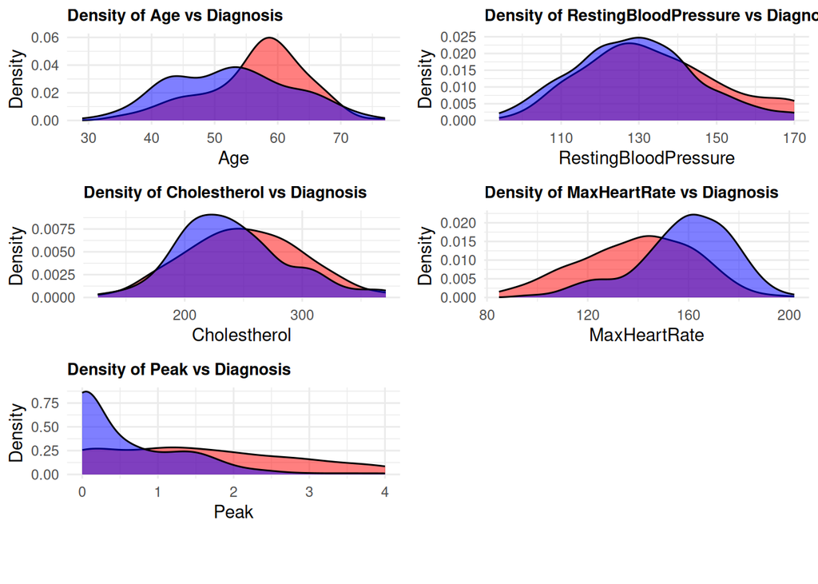

```r
# Ensure that Diagnosis is a factor to guarantee the generation of the legend
heart_df_filtered$Diagnosis <- as.factor(heart_df_filtered$Diagnosis)

# List of continuous variables to analyze in relation to heart disease diagnosis
continuous_vars <- c("Age", "RestingBloodPressure", "Cholestherol", "MaxHeartRate", "Peak")

# Function to create a density plot showing the distribution of a continuous variable by diagnosis
create_density_plot <- function(variable) {
  ggplot(heart_df_filtered, aes(x = !!sym(variable), fill = Diagnosis)) +
    geom_density(alpha = 0.5) +  # Use 50% transparency to facilitate distribution comparison
    labs(title = paste("Density of", variable, "vs Diagnosis"),
         x = variable,
         y = "Density") +
    scale_fill_manual(values = c("NoDisease" = "blue", "Disease" = "red")) +  # Assign specific colors to each group
    theme_minimal() +
    theme(
      plot.title = element_text(size = 10, face = "bold"),  # Reduce title size
      legend.position = "none"  # Hide legend in individual plots
    )
}

# Generate density plots for each variable in the list
density_plots <- lapply(continuous_vars, create_density_plot)

# Create an auxiliary plot ONLY for the legend
legend_plot <- ggplot(heart_df_filtered, aes(x = Age, fill = Diagnosis)) +
  geom_density(alpha = 0.5) +
  scale_fill_manual(values = c("NoDisease" = "blue", "Disease" = "red"), name = "Diagnosis") +
  theme_minimal() +
  guides(fill = guide_legend(title = "Diagnosis")) +  # Ensure the legend has a title
  theme(legend.position = "bottom")

# Extract the legend from the auxiliary plot
legend <- get_legend(legend_plot)
# Combine all plots and the legend into a grid
final_plot <- plot_grid(
  plot_grid(plotlist = density_plots, ncol = 2),  # Arrange plots in 2 columns
  legend,  # Global legend
  ncol = 1,  # Organize into a single column
  rel_heights = c(10, 1)  # Adjust relative size between plots and legend
)

# Display the final plot
print(final_plot)
```

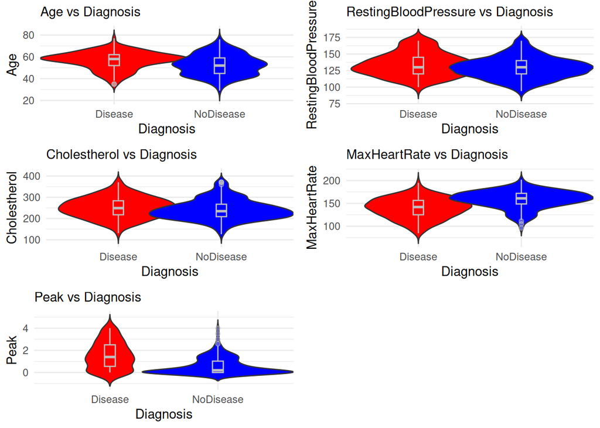

```r
# List of continuous variables to analyze in relation to heart disease diagnosis
continuous_vars <- c("Age", "RestingBloodPressure", "Cholestherol", "MaxHeartRate", "Peak")

# Function to create a violin plot showing the distribution of a continuous variable by diagnosis
create_violin_plot <- function(variable) {
  ggplot(heart_df_filtered, aes(x = Diagnosis, y = !!sym(variable), fill = Diagnosis)) +
    geom_violin(width = 1.4, trim = FALSE) +  # Use a violin plot without trimming the extremes
    geom_boxplot(width = 0.1, color = "grey", alpha = 0.5, position = position_dodge(width = 0.9)) +  # Adjust the boxplot position
    scale_fill_manual(values = c("NoDisease" = "blue", "Disease" = "red")) +  # Define red and blue colors
    scale_x_discrete(expand = expansion(add = 0.3)) +  # Add extra space on the x-axis to prevent overlap
    theme_minimal() +  # Apply a clean and professional theme
    theme(
      legend.position = "none",  # Hide individual legends for each plot
      plot.title = element_text(size = 11)  # Adjust title size to avoid overlap
    ) +
    ggtitle(paste(variable, "vs Diagnosis"))  # Set the plot title
}

# Generate violin plots for each variable in the list
violin_plots <- lapply(continuous_vars, create_violin_plot)

# Display all plots in a grid with two columns
plot_grid(plotlist = violin_plots, ncol = 2)
```

CONCLUSIONS: Since the number of males is higher than the number of females in this dataset, the analysis may be subject to bias. However, we have observed that heart disease is more prevalent in men than in women within this dataset.

- Most individuals in the disease group reported asymptomatic chest pain.
- Patients with thalassemia defects are more prone to heart disease.
- Non-anginal chest pain has a lower proportion of disease cases compared to typical anginal pain.
- An increased number of major vessels is associated with a higher proportion of disease, as it indicates a narrower diameter in the major vessels.
- Patients who experienced exercise-induced angina have a higher prevalence of heart disease compared to those who did not.

Regarding continuous variables: - Age and Maximum Heart Rate appear to be strongly associated with a higher risk of heart disease. - Cholesterol levels are distributed differently between the disease and no-disease groups. - The Peak variable, which represents the magnitude of ST-segment depression, is found to be higher in the disease group, suggesting its potential relevance as a predictive feature.

# 2 Difference in mortality rates in hospitalized COVID-19 patients

Using the supplementary material from the [Difference in mortality rates in hospitalized COVID-19 patients identified by cytokine profile clustering using a machine learning approach: An outcome prediction alternative](https://www.frontiersin.org/articles/10.3389/fmed.2022.987182/full), perform the following tasks

## Reproduce Figure 1 from the publication

```r
library(readxl)
Table_1 <- read_excel("Article/Table 1.XLSX", skip = 1, na = "NI")

#summary(Table_1)
# Fixing errors in the data
Table_1 <- Table_1[!duplicated(Table_1$ID), ] # Remove duplicated ID records

Table_1$Gender <- gsub(72, NA, Table_1$Gender)

Table_1$BMI <- gsub(",", ".", Table_1$BMI) # Change comma to decimal
Table_1$BMI <- gsub(0, NA, Table_1$BMI) # Make 0 BMI a NA value
Table_1$BMI <- as.numeric(Table_1$BMI)

Table_1[Table_1$ID == 'COAG-HSJD-180', "Admission to ICU"] <- "Yes" # Incorrect addition of a random number before Yes
Table_1[Table_1$ID == 'COAG-HSJD-076', "Admission to ICU"] <- NA # Incorrect data

Table_1[!Table_1$`ARDS Diagnosis` %in% c("Yes", "No"), "ARDS Diagnosis"] <- NA # Incorrect data

Table_1$`Use of NIV` <- gsub(8, NA, Table_1$`Use of NIV`)

Table_1$Death <- gsub(3, NA, Table_1$Death)

library(patchwork)
```

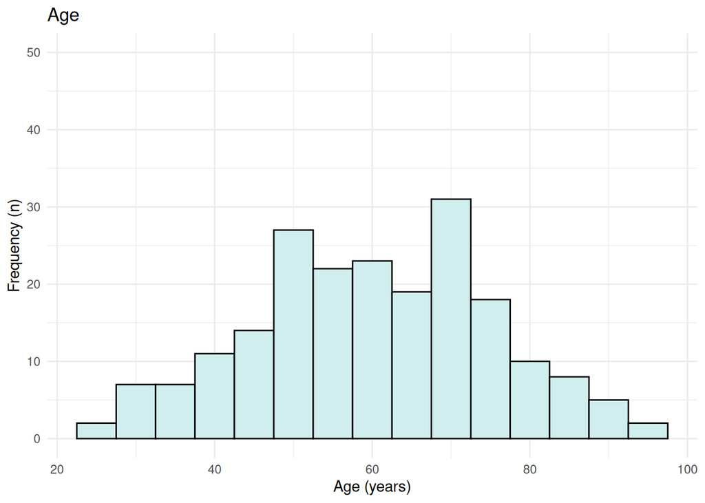

```r
library(ggplot2)
# Replicate figure A
# Crear el histograma usando ggplot2
plot_A <- ggplot(Table_1, aes(x = Age)) +
  geom_histogram(binwidth = 5, fill = "lightcyan2", color = "black") +
  labs(
    title = "Age",
    x = "Age (years)",
    y = "Frequency (n)"
  ) +
  ylim(0, 50) +
  theme_minimal()

# Mostrar el gráfico
print(plot_A)
```

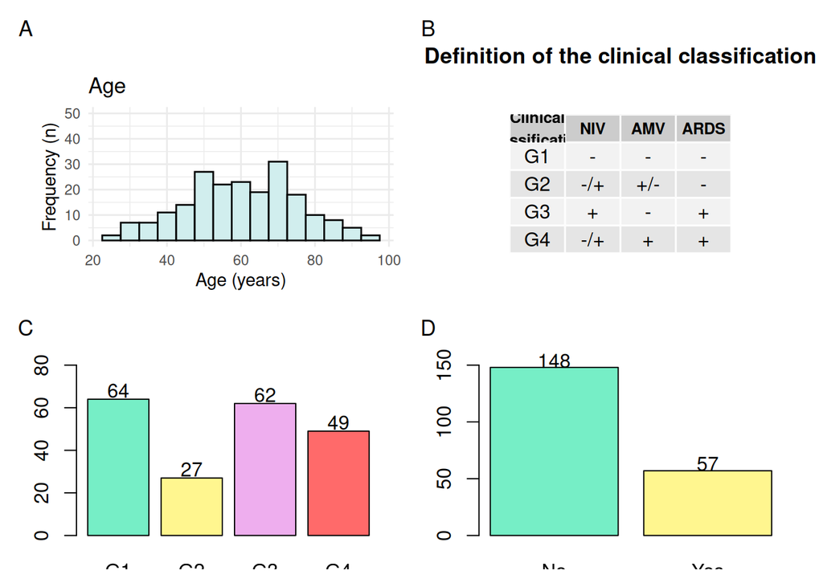

```r
# Replicate figure B
library(gridExtra)
library(grid)
library(ggplotify)

grid_table <- data.frame(
  Clinical= c('G1', 'G2', 'G3', 'G4'),
  NIV = c('-', '-/+', '+', '-/+'),
  AMV = c('-', '+/-', '-', '+'),
  ARDS = c('-', '-', '+', '+')
)
colnames(grid_table)[1] = 'Clinical\nclassification'
theme <- gridExtra::ttheme_default(
    core = list(fg_params=list(cex = 1.0)),
    colhead = list(fg_params=list(cex = 0.8)),
    rowhead = list(fg_params=list(cex = 0.8)))
grob <- tableGrob(grid_table, theme = theme, rows = NULL)
grob$widths <- unit(rep(0.6 / ncol(grob), ncol(grob)), "npc")
grob$heights <- unit(rep(0.6 / nrow(grob), nrow(grob)), "npc") # new
plot_B <- as.ggplot(grob) + ggtitle("Definition of the clinical classification") + theme(plot.title = element_text(hjust = 0.5, face = "bold"))

# Replicate figure C
assign_group <- function(NIV, AMV, ARDS) {
  if (is.na(NIV) || is.na(AMV) || is.na(ARDS)) {
    return(NA)
  }
  if (NIV == "No" && AMV == "No" && ARDS == "No") {
    return("G1")
  } else if ((NIV %in% c("No", "Yes")) && (AMV %in% c("No", "Yes")) && ARDS == "No") {
    return("G2")
  } else if (NIV == "Yes" && AMV == "No" && ARDS == "Yes") {
    return("G3")
  } else if ((NIV %in% c("No", "Yes")) && AMV == "Yes" && ARDS == "Yes") {
    return("G4")
  } else {
    return(NA)
  }
}

Table_1$Group <- mapply(assign_group, Table_1$`Use of NIV`, Table_1$`Use of AMV`, Table_1$`ARDS Diagnosis`)

bar_tb <- table(Table_1$Group)
bar_df <- data.frame(
  names = names(bar_tb),
  numbers = as.numeric(bar_tb)
)
plot_C <- function() {
  plot_C <- barplot(
    names = bar_df$names,
    height = bar_df$numbers,
    ylim = c(0, 80),
    main = "Clinical classification",
    xlab = "Clinical classification",
    ylab = "Frequency (n)",
    col = c("aquamarine2", "khaki1", "plum2", "indianred1"))

  text(plot_C, bar_df$numbers + 4, labels = bar_df$numbers, cex = 1)
}
plot_C <- as.ggplot(~plot_C())

bar_tb_d <- table(Table_1$Death)
bar_df_d <- data.frame(
  names = names(bar_tb_d),
  numbers = as.numeric(bar_tb_d)
)

plot_D <- function() {
  plot_D <- barplot(
    names = bar_df_d$names,
    height = bar_df_d$numbers,
    ylim = c(0, 150),
    xlab = "Death",
    ylab = "Frequency (n)",
    col = c("aquamarine2", "khaki1"),
    main = "Vital status",
    yaxt = "n"
  )
  text(plot_D, bar_df_d$numbers + 6, labels = bar_df_d$numbers, cex = 1)
  axis(2, at = seq(0, 150, by = 50), labels = seq(0, 150, by = 50))
}
plot_D <- as.ggplot(~plot_D())

wrap_elements(panel = plot_A, clip = FALSE) +
  plot_B +
  wrap_elements(panel = plot_C, clip = FALSE) +
  wrap_elements(panel = plot_D, clip = FALSE) +
  plot_annotation(tag_levels = 'A') # Tag plots
```

## Reproduce Figure 2 from the publication

but instead of representing the clusters in the annotation, represent the groups (G1 to G4)

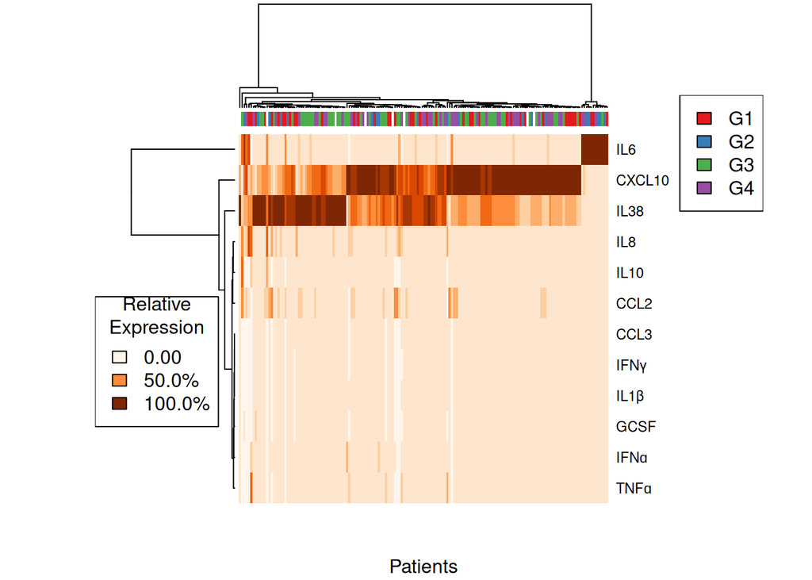

```r
# Cargar librerías necesarias
library(readxl)
library(dplyr)
library(tidyr)
library(pheatmap)
library(openxlsx)
library(RColorBrewer)


# Cargar datos
Table_2 <- read_excel("Article/Table 2.XLSX", skip = 1, na = "NI")
#Table_21 <- read.xlsx("Table 2.xlsx" , startRow = 2)

#Cleaning Table 2:
#Change the first column name of "Table 2" to "ID"
colnames(Table_2)[1] <- "ID"
# Remove rows with NA in the ID column and extract unique records.
Table_2 <- Table_2 %>%
  filter(!is.na(ID)) %>%
  distinct(ID, .keep_all = TRUE) %>%
  select(ID,`IL-6`,CXCL10,`IL-38`,`IL-8`,`IFN-ɑ`,`IL-10`,`TNF-ɑ`,CCL2,CCL3,`IFN-γ`,`IL-1β`,`G-CSF`)

# Define the columns to check as strings
columns_to_check <- c("IL-6", "CXCL10", "IL-38", "IL-8", "IFN-ɑ", "IL-10", "TNF-ɑ", "CCL2", "CCL3", "IFN-γ", "IL-1β", "G-CSF")

# Delete rows with characters in specified columns
unique_table2 <- Table_2 %>%
  filter(!if_any(all_of(columns_to_check), ~grepl("^[A-Za-z]+$", .)))

# Delete the rows with "NA" in specified columns
unique_table2.2 <- unique_table2 %>%
  filter(!if_any(all_of(columns_to_check), is.na))

# Identify common IDs in both tables
common_ids <- intersect(Table_1$ID, unique_table2.2$ID)
# Filter tables to keep only rows with common IDs
filtered_table2 <- unique_table2.2 %>% filter(ID %in% common_ids)

# Select the needed columns and rename the labels to make them more easy to handle
unique_table2.2 <- unique_table2.2 %>%
  select(ID,`IL-6`,CXCL10,`IL-38`,CCL3,`IFN-γ`,`IL-1β`,`IL-10`,`G-CSF`,`IFN-ɑ`
         ,`TNF-ɑ`,`IL-8`,CCL2) %>%
  rename_all(~ gsub("-", "", .)) %>%
  #Turn all non numeric values to NA
  mutate(across(-ID,as.numeric))

#Merge table 2 with classification from table 1 with ID.
# Agregar la columna Group de Table_1 a unique_table2.2 usando ID como clave
unique_table2.2 <- unique_table2.2 %>%
  left_join(Table_1 %>% select(ID, Group), by = "ID")



#Define color pallette and assign a color to each group
color <- brewer.pal(4, "Set1")
classification_colors <- setNames(color, c("G1", "G2", "G3", "G4"))
classifications <- unique_table2.2$Group
classification_colside <- classification_colors[classifications]

#Plot using Heatmap
heatmap_plot <- heatmap(
  as.matrix(t(unique_table2.2[, 2:13])),
  cexCol = 0.1,
  xlab = "Patients",
  labCol = FALSE,
  col = brewer.pal(9, "Oranges"),
  scale = "column",
  ColSideColors = classification_colside,
)

legend("topright",legend=c("G1", "G2", "G3", "G4"),fill=classification_colors)
legend(legend = c("0.00", "50.0%", "100.0%"),
       fill = (brewer.pal(9,"Oranges")[c(1,5,9)]), title = "Relative\nExpression",
       x = 0, y = 0.45)
```

## Improve figure 2 of the publication

Add a second annotation with information of deathm and a third one with information of gender

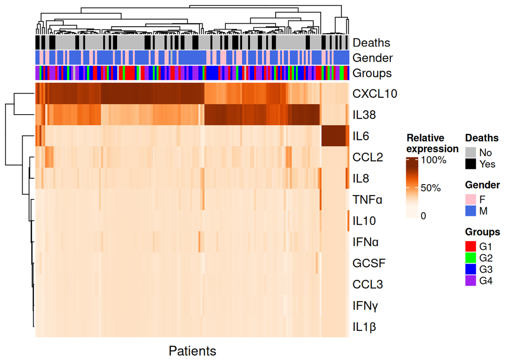

```r
library(ComplexHeatmap)
library(RColorBrewer)

#Clean table.
unique_table1.3 <- Table_1 %>%
  filter(!is.na(ID)) %>%
  distinct(ID, .keep_all = TRUE)

#Merge by ID only columns of gender and death from Table 1.
table12_group_gender <- inner_join(
  unique_table2.2,
  unique_table1.3 %>% select(ID, Gender, Death),
  by = "ID"
)

#Remove numeric character and right strip space character.
table12_group_gender <- table12_group_gender %>%
  filter(!grepl("\\d", Gender))

#Get numeric data for Heatmap.
numeric_data <- table12_group_gender[, -c(1, 14, 15, 16)]

#Annotations.
gender_info <- table12_group_gender$Gender
death_info <- table12_group_gender$Death
classification_info <- table12_group_gender$Group
gender_info <- replace(gender_info, gender_info =="F ", "F")

ha <- HeatmapAnnotation(
    Deaths = death_info ,
    Gender = gender_info,
    Groups = classification_info,
    col = list(Deaths = c("Yes" = "black", "No" = "gray"),
               Groups = c("G1" = "red", "G2" = "green", "G3" = "blue", "G4" = "purple"),
               Gender = c("M" = "royalblue", "F" = "pink")
    )
)

Heatmap(
  scale(as.matrix(t(numeric_data))),
  name = "Relative\nexpression",
  column_title = "Patients",
  column_title_side = "bottom",
  top_annotation = ha,
  col = brewer.pal(9, "Oranges"),

  heatmap_legend_param = list(
    title = "Relative\nexpression",
    at = c(-2,1,4),
    labels = c("0", "50%", "100%")
  )

)
```

# session info

R version 4.4.3 (2025-02-28) Platform: x86_64-pc-linux-gnu Running under: Ubuntu 24.04.2 LTS

Matrix products: default BLAS: /usr/lib/x86_64-linux-gnu/blas/libblas.so.3.12.0 LAPACK: /usr/lib/x86_64-linux-gnu/lapack/liblapack.so.3.12.0

locale: [1] LC_CTYPE=en_US.UTF-8 LC_NUMERIC=C  
[3] LC_TIME=en_US.UTF-8 LC_COLLATE=en_US.UTF-8  
[5] LC_MONETARY=en_US.UTF-8 LC_MESSAGES=en_US.UTF-8  
[7] LC_PAPER=en_US.UTF-8 LC_NAME=C  
[9] LC_ADDRESS=C LC_TELEPHONE=C  
[11] LC_MEASUREMENT=en_US.UTF-8 LC_IDENTIFICATION=C

time zone: Europe/Madrid tzcode source: system (glibc)

attached base packages: [1] grid stats graphics grDevices utils datasets methods  
[8] base

other attached packages: [1] RColorBrewer_1.1-3 openxlsx_4.2.8 pheatmap_1.0.12  
[4] ggplotify_0.1.2 patchwork_1.3.0 readxl_1.4.5  
[7] ComplexHeatmap_2.20.0 viridis_0.6.5 viridisLite_0.4.2  
[10] hrbrthemes_0.8.7 cowplot_1.1.3 GGally_2.2.1  
[13] mice_3.17.0 gridExtra_2.3 tidyr_1.3.1  
[16] dplyr_1.1.4 ggplot2_3.5.1

loaded via a namespace (and not attached): [1] Rdpack_2.6.3 rlang_1.1.5 magrittr_2.0.3  
[4] clue_0.3-66 GetoptLong_1.0.5 matrixStats_1.5.0  
[7] compiler_4.4.3 png_0.1-8 systemfonts_1.2.1  
[10] vctrs_0.6.5 pkgconfig_2.0.3 shape_1.4.6.1  
[13] crayon_1.5.3 fastmap_1.2.0 magick_2.8.5  
[16] backports_1.5.0 labeling_0.4.3 rmarkdown_2.29  
[19] nloptr_2.2.1 purrr_1.0.4 xfun_0.51  
[22] glmnet_4.1-8 jomo_2.7-6 cachem_1.1.0  
[25] jsonlite_1.9.1 pan_1.9 broom_1.0.7  
[28] parallel_4.4.3 cluster_2.1.8 R6_2.6.1  
[31] bslib_0.9.0 stringi_1.8.4 boot_1.3-31  
[34] extrafontdb_1.0 rpart_4.1.24 jquerylib_0.1.4  
[37] cellranger_1.1.0 Rcpp_1.0.14 iterators_1.0.14  
[40] knitr_1.50 extrafont_0.19 IRanges_2.38.1  
[43] Matrix_1.7-2 splines_4.4.3 nnet_7.3-20  
[46] tidyselect_1.2.1 rstudioapi_0.17.1 yaml_2.3.10  
[49] doParallel_1.0.17 codetools_0.2-20 lattice_0.22-5  
[52] tibble_3.2.1 plyr_1.8.9 withr_3.0.2  
[55] evaluate_1.0.3 gridGraphics_0.5-1 survival_3.8-3  
[58] ggstats_0.9.0 zip_2.3.2 circlize_0.4.16  
[61] pillar_1.10.1 BiocManager_1.30.25 foreach_1.5.2  
[64] stats4_4.4.3 reformulas_0.4.0 generics_0.1.3  
[67] S4Vectors_0.42.1 munsell_0.5.1 scales_1.3.0  
[70] minqa_1.2.8 glue_1.8.0 gdtools_0.4.1  
[73] tools_4.4.3 lme4_1.1-36 fs_1.6.5  
[76] Rttf2pt1_1.3.12 rbibutils_2.3 colorspace_2.1-1  
[79] nlme_3.1-167 cli_3.6.4 fontBitstreamVera_0.1.1 [82] gtable_0.3.6 yulab.utils_0.2.0 sass_0.4.9  
[85] digest_0.6.37 fontquiver_0.2.1 BiocGenerics_0.50.0  
[88] rjson_0.2.23 farver_2.1.2 htmltools_0.5.8.1  
[91] lifecycle_1.0.4 GlobalOptions_0.1.2 mitml_0.4-5  
[94] fontLiberation_0.1.0 MASS_7.3-65